# Classification of Spotify songs into genres

Author

Shrikar Banagiri

Published

November 11, 2023

## **Introduction**

This [Spotify song dataset](https://www.kaggle.com/datasets/joebeachcapital/30000-spotify-songs/?select=spotify_songs.csv) contains over 30,000 songs from artists of different genres. Each song has specific attributes which help the user discern its genre. These attributes include `danceability`, `energy`, `loudness`, `key`, `mode`, `speechiness`, `acousticness`, `instrumentalness`, `liveness`, `valence`, and `tempo`.

The problem statement is to classify the songs (based on the above attributes) into six genres: `pop`, `rock`, `latin`, `EDM`, `rap`, and `R&B`.

## Importing the dataset

First, we import the libraries required to perform the initial data analysis. The dataset, hosted on [Kaggle](https://www.kaggle.com/), is imported and stored in the variable `spotify_songs`.

```python
# Import the libraries

import numpy as np
import pandas as pd
import seaborn as sns
import matplotlib.pyplot as plt
import urllib.request
from pathlib import Path
import os
import zipfile

# Downloading and opening the dataset

csv_path = Path('datasets/archive.zip') # store the dataset in a local folder
url = 'https://www.kaggle.com/datasets/joebeachcapital/30000-spotify-songs/download?datasetVersionNumber=2' # url to download the dataset

if not csv_path.is_file(): # check if the dataset directory exists.
  Path("datasets").mkdir(parents=True,exist_ok=True) # Create the directory
  urllib.request.urlretrieve(url, csv_path)
  with zipfile.ZipFile(csv_path) as spotify_file:
    spotify_file.extractall(path='datasets')

spotify_songs = pd.read_csv(Path('datasets/spotify_songs.csv')) # Store the dataset in a variable
```

## Analyzing the Data

Let’s look at the non-null entries in the dataset using the `info()` method below.

```python
spotify_songs.info()
```

```
<class 'pandas.core.frame.DataFrame'>
RangeIndex: 32833 entries, 0 to 32832
Data columns (total 23 columns):
 #   Column                    Non-Null Count  Dtype
---  ------                    --------------  -----
 0   track_id                  32833 non-null  object
 1   track_name                32828 non-null  object
 2   track_artist              32828 non-null  object
 3   track_popularity          32833 non-null  int64
 4   track_album_id            32833 non-null  object
 5   track_album_name          32828 non-null  object
 6   track_album_release_date  32833 non-null  object
 7   playlist_name             32833 non-null  object
 8   playlist_id               32833 non-null  object
 9   playlist_genre            32833 non-null  object
 10  playlist_subgenre         32833 non-null  object
 11  danceability              32833 non-null  float64
 12  energy                    32833 non-null  float64
 13  key                       32833 non-null  int64
 14  loudness                  32833 non-null  float64
 15  mode                      32833 non-null  int64
 16  speechiness               32833 non-null  float64
 17  acousticness              32833 non-null  float64
 18  instrumentalness          32833 non-null  float64
 19  liveness                  32833 non-null  float64
 20  valence                   32833 non-null  float64
 21  tempo                     32833 non-null  float64
 22  duration_ms               32833 non-null  int64
dtypes: float64(9), int64(4), object(10)
memory usage: 5.8+ MB
```

The output shows that the columns `track_name`, `track_artist`, and `track_album_name` have 5 null elements (i.e., they only have 32828 elements). Let’s look at the genres and their counts in the dataset.

```python
spotify_songs['playlist_genre'].value_counts()
```

```
playlist_genre
edm      6043
rap      5746
pop      5507
r&b      5431
latin    5155
rock     4951
Name: count, dtype: int64
```

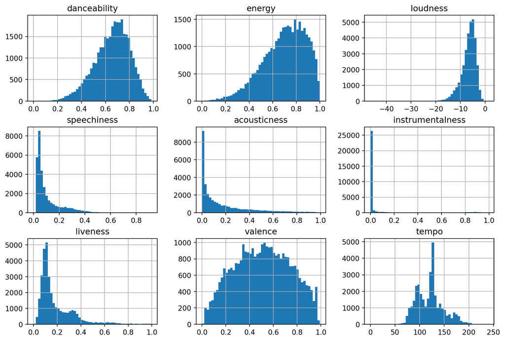

```python
spotify_features = spotify_songs.loc[:,['danceability','energy','loudness','speechiness','acousticness','instrumentalness','liveness','valence','tempo']]
spotify_features.hist(bins=50, figsize=(12, 8))
plt.show()
```

The following violin plot also describes the relationship between some of the attributes and genres. From the first violin plot, it is evident that `rap` music has a higher `danceability` score on average while the most danceable song belongs to the `edm` genre.

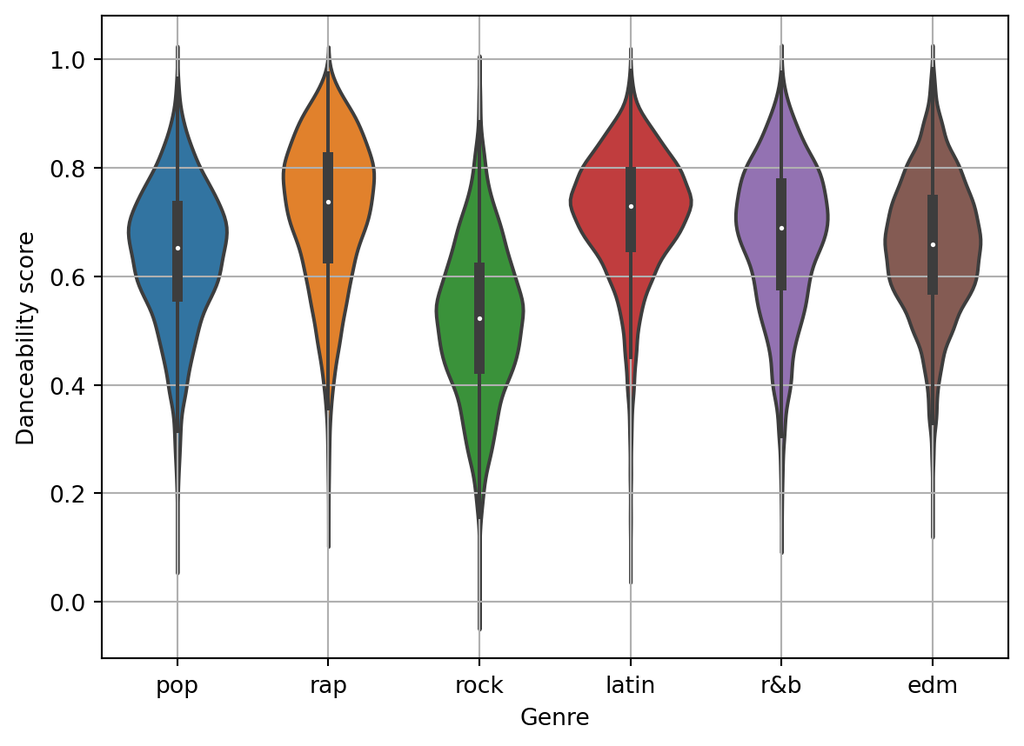

```python
sns.violinplot(x=spotify_songs.playlist_genre,y=spotify_songs.danceability)
plt.grid()
plt.xlabel('Genre')
plt.ylabel('Danceability score')
plt.show()
```

We should also look for any correlations within the features themselves. Ideally, all our features (i.e., attributes) must be independent of each other. However, it may happen that two or more features are highly correlated within themselves. In such a scenario, we will need to drop one of the correlated attributes.

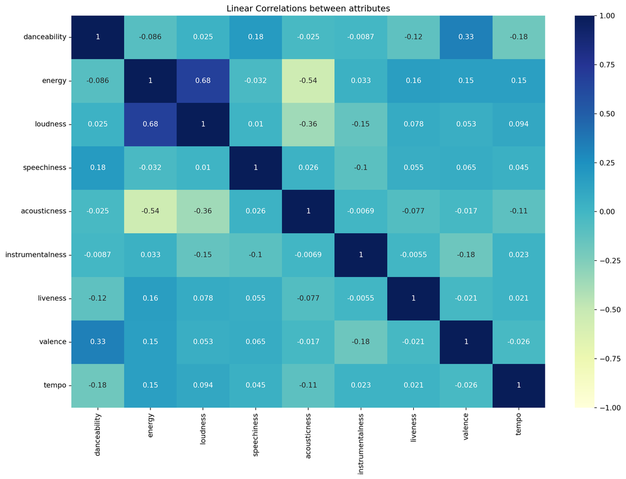

```python
fig, ax = plt.subplots(figsize=(15,10))
sns.heatmap(spotify_features.corr(), annot=True, cmap='YlGnBu', vmin=-1, vmax=1, center=0, ax=ax)
plt.title('Linear Correlations between attributes')
plt.show()
```

From the correlation matrix, we can note that the attributes `energy` and `loudness` are highly correlated. Their correlation coefficient is 0.68. Thus, we will drop the `loudness` attribute.

## Preprocessing the data

We will first drop the `loudness` attribute since it is highly correlated with the `energy` attribute.

```python
spotify_songs = spotify_songs.drop('loudness',axis=1)
```

The column `playlist_subgenre` has attributes such as dance pop and pop edm which are subsets of the parent column `playlist_genre`. Similarly,the `track_id`, `track_name`, `track_artist`, `track_popularity`, `track_album_id`, `track_album_name`, and `track_album_release_date` are not relevant. Thus, we drop all these columns. Furthermore, as we have seen before, there are null values in the `track_name`, `track_artist` , and `track_album_name` columns. Therefore, we need to drop the corresponding rows as well.

```python
spotify_songs.dropna(subset=['track_name','track_artist','track_album_name'], inplace=True) # Drop null values from the data
spotify_songs = spotify_songs.loc[:,'playlist_genre':'tempo'] # drop unnecessary columns
spotify_songs = spotify_songs.drop('playlist_subgenre',axis=1) # drop unnecessary columns
```

We can verify that the null values have been dropped by calling the `.info()` method again.

```python
spotify_songs.info()
```

```
<class 'pandas.core.frame.DataFrame'>
Index: 32828 entries, 0 to 32832
Data columns (total 11 columns):
 #   Column            Non-Null Count  Dtype
---  ------            --------------  -----
 0   playlist_genre    32828 non-null  object
 1   danceability      32828 non-null  float64
 2   energy            32828 non-null  float64
 3   key               32828 non-null  int64
 4   mode              32828 non-null  int64
 5   speechiness       32828 non-null  float64
 6   acousticness      32828 non-null  float64
 7   instrumentalness  32828 non-null  float64
 8   liveness          32828 non-null  float64
 9   valence           32828 non-null  float64
 10  tempo             32828 non-null  float64
dtypes: float64(8), int64(2), object(1)
memory usage: 3.0+ MB
```

Next, we will use `StandardScaler` transformer to standardize our attributes. Notice that the `spotify_features` dataframe in the following code does not include the `loudness` attribute.

```python
from sklearn.preprocessing import StandardScaler
from sklearn.preprocessing import MinMaxScaler
from scipy.stats import boxcox

std_scaler = StandardScaler()

spotify_features = spotify_songs.loc[:,['danceability','energy','speechiness','acousticness','instrumentalness','liveness','valence','tempo']] # collecting all the important features in a dataframe
spotify_songs.loc[:,['danceability','energy','speechiness','acousticness','instrumentalness','liveness','valence','tempo']] = std_scaler.fit_transform(spotify_features)

# Using boxcox to scale heavy-tailed features

min_max_scaler = MinMaxScaler()
spotify_new_features = spotify_songs.loc[:,'speechiness':'liveness']
spotify_tail_features = min_max_scaler.fit_transform(spotify_new_features)
spotify_tail_features = pd.DataFrame(spotify_tail_features,columns=spotify_new_features.columns)
transformed_acousticness = boxcox(spotify_tail_features.acousticness,0.25)
spotify_songs.acousticness = transformed_acousticness
transformed_liveness = boxcox(spotify_tail_features.acousticness,0.25)
spotify_songs.liveness = transformed_liveness
transformed_instrumentalness = boxcox(spotify_tail_features.instrumentalness,0.2)
spotify_songs.instrumentalness = transformed_instrumentalness
transformed_speechiness = boxcox(spotify_tail_features.speechiness,0.2)
spotify_songs.speechiness = transformed_speechiness
```

Now, we can take a look at the feature distributions. As we can see, the attributes are on the same scale and many of them are centered around zero. Most of these distributions are Gaussian.

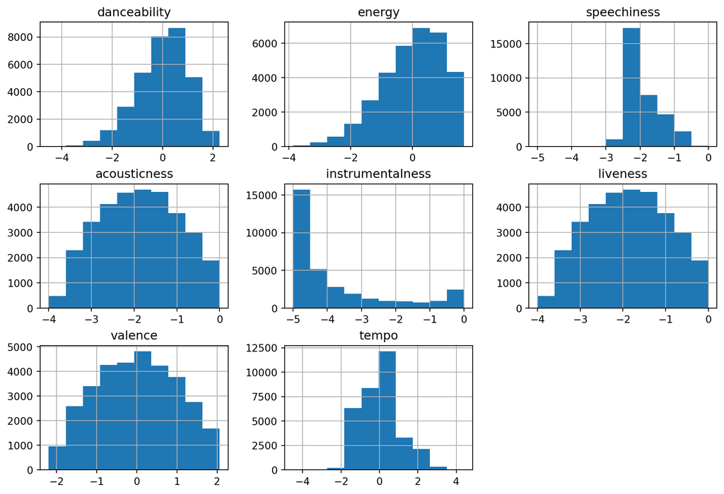

```python
spotify_features = spotify_songs.loc[:,['danceability','energy','speechiness','acousticness','instrumentalness','liveness','valence','tempo']]
spotify_features.hist(figsize=(12, 8))
plt.show()
```

## Creating Training and Test Sets

Now, we will create training and test sets. We will do this by limiting the test set size to 20 % of the total data set. Since we need an equal distribution of our target labels (i.e., the playlist genres), we will need to stratify the data with respect to the playlist genres.

```python
from sklearn.model_selection import train_test_split

train_set, test_set = train_test_split(spotify_songs, test_size=0.2, stratify = spotify_songs.playlist_genre,random_state=42)

X_train = train_set.drop('playlist_genre',axis=1)
y_train = train_set['playlist_genre']
X_test = test_set.drop('playlist_genre',axis=1)
y_test = test_set['playlist_genre']
```

## Train the models

Since this is a [multiclass classification problem](https://scikit-learn.org/stable/modules/multiclass.html#:~:text=Multiclass%20classification%20is%20a%20classification,an%20apple%2C%20or%20a%20pear.), support vector classifiers do not scale very well. Therefore, we will look for other classifiers. First, we’ll try logistic regression.

```python
from sklearn.linear_model import LogisticRegression

log_clf = LogisticRegression(max_iter=1000, random_state=42)
log_clf.fit(X_train, y_train); # Train the model
```

To measure the performance of the classifier, we will first import the `cross_val_score` function from scikit learn.

```python
from sklearn.model_selection import cross_val_score

cross_val_score(log_clf,X_train,y_train,cv=3,scoring='accuracy')
```

```
array([0.46047521, 0.45042266, 0.45807631])
```

For the 3 validation folds, Logistic Regression predicts the correct genres with 45 % accuracy on average. Let us compare this performance with a dummy classifier.

```python
from sklearn.dummy import DummyClassifier

dummy_clf = DummyClassifier()
dummy_clf.fit(X_train, y_train)

cross_val_score(dummy_clf, X_train, y_train, cv=3,scoring='accuracy')
```

```
array([0.18403016, 0.18414439, 0.18403016])
```

```python
from sklearn.model_selection import RandomizedSearchCV
from sklearn.tree import DecisionTreeClassifier
from scipy.stats import randint

decision_tree_clf = DecisionTreeClassifier(random_state=42)
param_random = {'max_features':randint(low=2,high=20)}
random_search_tree = RandomizedSearchCV(decision_tree_clf,param_distributions=param_random,n_iter=10,cv=5,scoring='accuracy')
random_search_tree.fit(X_train, y_train)

cross_val_score(random_search_tree, X_train, y_train, cv=3,scoring='accuracy')
```

```
array([0.41980809, 0.41089788, 0.41649532])
```

The `DecisionTreeClassifier` produces an average accuracy of 41 % on the validation folds. We will import the `RandomForestClassifier` , which aggregates a large number of decision trees together.

```python
from sklearn.ensemble import RandomForestClassifier

random_forest_clf = RandomForestClassifier(n_jobs=-1,random_state=42)
param_random = [{'n_estimators':randint(low=100, high=500)},{'max_leaf_nodes':randint(low=5,high=20)}]
random_search_forest = RandomizedSearchCV(random_forest_clf,param_distributions=param_random,n_iter=10,cv=3,scoring='accuracy')
random_search_forest.fit(X_train,y_train)

cross_val_score(random_search_forest, X_train, y_train, cv=3,scoring='accuracy')
```

```
array([0.53312771, 0.53152844, 0.52981494])
```

The `RandomForestClassifier` does better than the other models with an average accuracy of 53 % on the validation folds. Let us go one step further by using the `AdaBoostClassifier` with the `RandomForestClassifier` as the base estimator with a `learning_rate` of 0.5.

```python
from sklearn.ensemble import AdaBoostClassifier

best_estimator = random_search_forest.best_estimator_
ada_boost = AdaBoostClassifier(best_estimator,n_estimators=5,learning_rate = 0.5, random_state=42)
ada_boost.fit(X_train, y_train)
cross_val_score(ada_boost, X_train, y_train, cv=3,scoring='accuracy')
```

```
array([0.53518392, 0.53278501, 0.53689742])
```

```python
random_search_forest.score(X_test, y_test) # print the accuracy score on the test set
```

```
0.5275662503807493
```

## Error Analysis

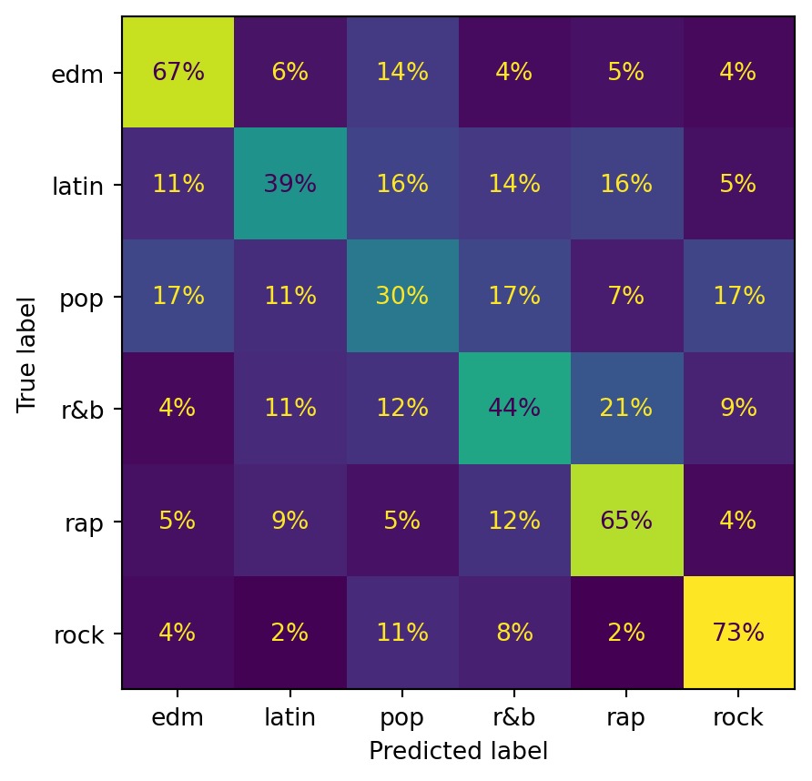

```python
from sklearn.model_selection import cross_val_predict
from sklearn.metrics import ConfusionMatrixDisplay

y_preds = cross_val_predict(random_search_forest.best_estimator_,X_train, y_train, cv=3)

ConfusionMatrixDisplay.from_predictions(y_train,y_preds,normalize='true',values_format='.0%',colorbar=None) # normalize predictions by row
plt.show()
```